# Lecture: Doing Bayesian data analysis with brms

## 1 Learning Goals

- understand the basic functionality of the brms package
- specify and estimate Bayesian regression models with brms
- interpret model output and posterior summaries
- carry out a basic Bayesian workflow in brms

## 2 Overview

### 2.1 What is brms?

> <sub>The brms package provides an interface to fit Bayesian generalized (non-)linear multivariate multilevel models using Stan. The formula syntax is very similar to that of the package lme4 to provide a familiar and simple interface for performing regression analyses.</sub>

<sub><sup>paul-buerkner.github.io/brms</sup></sub>

It was created and is being maintained by [Paul Bürkner](https://paul-buerkner.github.io/). It is extensively documented on its own [website](https://paul-buerkner.github.io/brms/).

### 2.2 Comparison: Pre-implemented model types

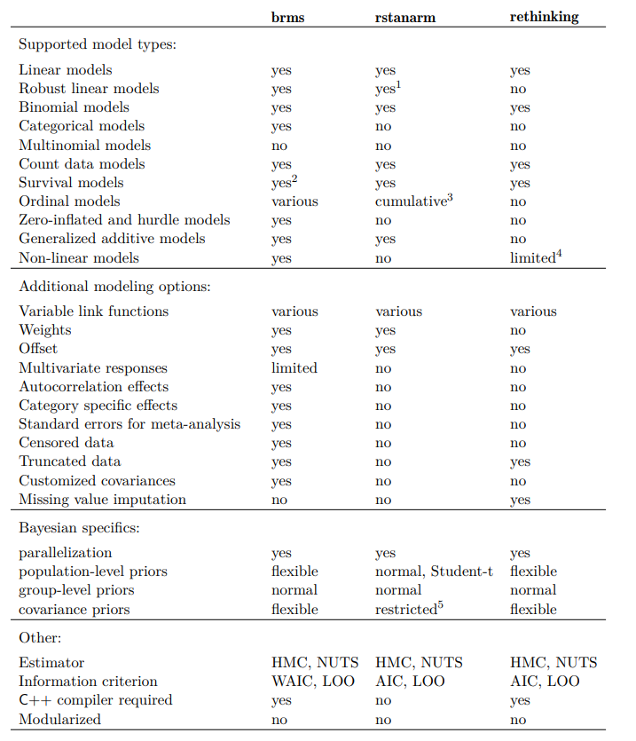

<sub><sup>Source: [Bürkner, Paul-Christian (2022). brms: An R Package for Bayesian Multilevel Models using Stan.](https://cloud.r-project.org/web/packages/brms/vignettes/brms_overview.pdf)</sup></sub>

*Note:* This table is from a 2022 publication. Newer versions of `brms` handle [missing values](https://cloud.r-project.org/web/packages/brms/vignettes/brms_missings.html).

### 2.3 brms vignettes as an indication of its versatility

#### 2.3.1 General

- [General Introduction to brms](https://www.jstatsoft.org/article/view/v080i01)

#### 2.3.2 Model types

- [Advanced Multilevel Modeling with brms](https://journal.r-project.org/archive/2018/RJ-2018-017/index.html)
- [Bayesian Item Response Modeling with brms](https://arxiv.org/abs/1905.09501)
- [Estimating Distributional Models with brms](https://paul-buerkner.github.io/brms/articles/brms_distreg.html)
- [Estimating Multivariate Models with brms](https://paul-buerkner.github.io/brms/articles/brms_multivariate.html)
- [Estimating Non-Linear Models with brms](https://paul-buerkner.github.io/brms/articles/brms_nonlinear.html)
- [Estimating Phylogenetic Multilevel Models with brms](https://paul-buerkner.github.io/brms/articles/brms_phylogenetics.html)

#### 2.3.3 Auxiliary

- [Define Custom Response Distributions with brms](https://paul-buerkner.github.io/brms/articles/brms_customfamilies.html)
- [Parameterization of Response Distributions in brms](https://paul-buerkner.github.io/brms/articles/brms_families.html)
- [Handle Missing Values with brms](https://paul-buerkner.github.io/brms/articles/brms_missings.html)
- [Estimating Monotonic Effects with brms](https://paul-buerkner.github.io/brms/articles/brms_monotonic.html)
- [Running brms models with within-chain parallelization](https://paul-buerkner.github.io/brms/articles/brms_threading.html)

### 2.4 A function call to brms

```r
lm_brms <- brms::brm(
  sup_afd ~                              # outcome
    la_self,                             # predictor
  data = gles,                           # data
  family = gaussian(link = "identity"),  # family and link
  chains = 4L,                           # number of chains
  iter = 2000L,                          # number of iterations per chain
  warmup = 1000L,                        # number of warm-up samples per chain
  algorithm = "sampling",                # algorithm (HMC/NUTS)
  backend = "rstan",                     # backend (rstan)
  seed = 20231123L                       # seed
)
```

### 2.5 What happens under the hood

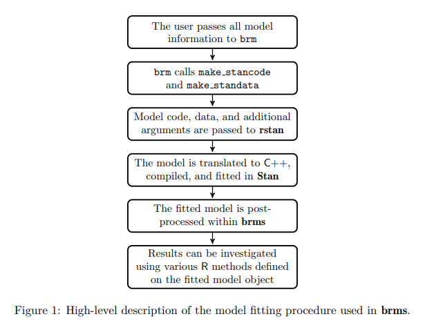

<sub><sup>Source: [Bürkner, Paul-Christian (2022). brms: An R Package for Bayesian Multilevel Models using Stan.](https://cloud.r-project.org/web/packages/brms/vignettes/brms_overview.pdf)</sup></sub>

## 3 Linear model

### 3.1 Data

We model respondents’ support for the AfD (`sup_afd`, measured on an 11-point scale ranging from -5 to 5) as a function of respondents’ pro-redistribution preferences (`se_self`) and anti-immigration preferences (`la_self`), a multiplicative interaction term between the two, and some controls: Gender (`fem`), age (`age`), and East/West residence (`east`).

Both `se_self` and `la_self` are measured on 11-point scales:

- `se_self` ranges from values (0) “less taxes and deductions, even if that means less social spending” to (10) “more social spending, even if that means more taxes and deductions”.
- `la_self` ranges from values (0) “facilitate immigration” to (10) “restrict immigration”.

The model formula is given by

$$\mathtt{sup\_afd}_i = \\\beta_1 + \beta_2 \mathtt{se\_self}_i + \beta_3
\mathtt{la\_self}_i + \\ \beta_4 \mathtt{fem}_i + \beta_5
\mathtt{east}_i + \beta_6 \mathtt{age}_i + \\ \beta_7
\mathtt{se\_self}_i \times \mathtt{la\_self}_i + \epsilon$$

## 4 Fitting

### 4.1 Choosing priors

`brms` uses default priors for certain “classes” of parameters. To check these defaults, we need to supply the model formula, data, and generative model (i.e., family and link function) to `brms::get_prior()`.

```
##                  prior     class            coef group resp dpar nlpar lb ub
##                 (flat)         b
##                 (flat)         b             age
##                 (flat)         b           east1
##                 (flat)         b            fem1
##                 (flat)         b         la_self
##                 (flat)         b la_self:se_self
##                 (flat)         b         se_self
##  student_t(3, -5, 2.5) Intercept
##   student_t(3, 0, 2.5)     sigma                                        0
##        source
##       default
##  (vectorized)
##  (vectorized)
##  (vectorized)
##  (vectorized)
##  (vectorized)
##  (vectorized)
##       default
##       default
```

*Note:* Missing entries in the `prior` column denote flat/uniform priors.

### 4.2 Define custom priors

If we don’t like the default priors, we can create a `brmsprior` object by specifying the desired distributional properties of parameters of various classes:

```
##         prior     class coef group resp dpar nlpar   lb   ub source
##  normal(0, 5)         b                            <NA> <NA>   user
##  normal(0, 5) Intercept                            <NA> <NA>   user
##  cauchy(0, 5)     sigma                               0 <NA>   user
```

Let’s think about these values intuitively. How informative/vague are our priors?

### 4.3 Prior predictive checks: Fitting

### 4.4 Check model predictions vis-à-vis empirical distribution of outcome

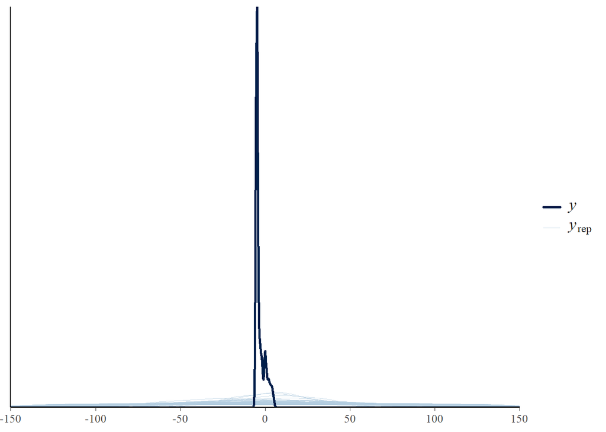

```r
brms::pp_check(
  lm_brms_prior_only,
  ndraws = 100,
  type = "dens_overlay"
) +
  ggplot2::xlim(-150, 150)
```

### 4.5 Fitting the model

Lastly, we can fit the model using `brms::brm()`.

*Note:* Model compilation and estimation may take a while.

## 5 Summarize and diagnose

### 5.1 Model summary and generic diagnostics

First, we print the model summary. We can check `Rhat` for any signs of non-convergence.

```
##  Family: gaussian
##   Links: mu = identity; sigma = identity
## Formula: sup_afd ~ la_self * se_self + fem + east + age
##    Data: gles (Number of observations: 1321)
##   Draws: 4 chains, each with iter = 2000; warmup = 1000; thin = 1;
##          total post-warmup draws = 4000
##
## Regression Coefficients:
##                 Estimate Est.Error l-95% CI u-95% CI Rhat Bulk_ESS Tail_ESS
## Intercept          -3.81      0.43    -4.63    -2.95 1.00     2719     2473
## la_self             0.30      0.05     0.20     0.41 1.00     2474     2331
## se_self            -0.12      0.06    -0.25     0.01 1.00     2575     2151
## fem1               -0.59      0.14    -0.87    -0.32 1.00     4804     2719
## east1               0.42      0.15     0.14     0.71 1.00     4394     2740
## age                -0.01      0.00    -0.02    -0.01 1.00     5887     3038
## la_self:se_self     0.01      0.01    -0.01     0.03 1.00     2483     2183
##
## Further Distributional Parameters:
##       Estimate Est.Error l-95% CI u-95% CI Rhat Bulk_ESS Tail_ESS
## sigma     2.44      0.05     2.36     2.53 1.00     5010     3136
##
## Draws were sampled using sampling(NUTS). For each parameter, Bulk_ESS
## and Tail_ESS are effective sample size measures, and Rhat is the potential
## scale reduction factor on split chains (at convergence, Rhat = 1).
```

*Quick guides on interpretation:*

- [Potential scale reduction factor (`Rhat`)](https://mc-stan.org/bayesplot/articles/visual-mcmc-diagnostics.html#mcmc_rhat-mcmc_rhat_hist)
- [Effective sample size (`Bulk_ESS`, `Tail_ESS`)](https://mc-stan.org/bayesplot/articles/visual-mcmc-diagnostics.html#effective-sample-size)

### 5.2 Visual diagnostics

Let’s explore the following visualizations of common generic diagnostics:

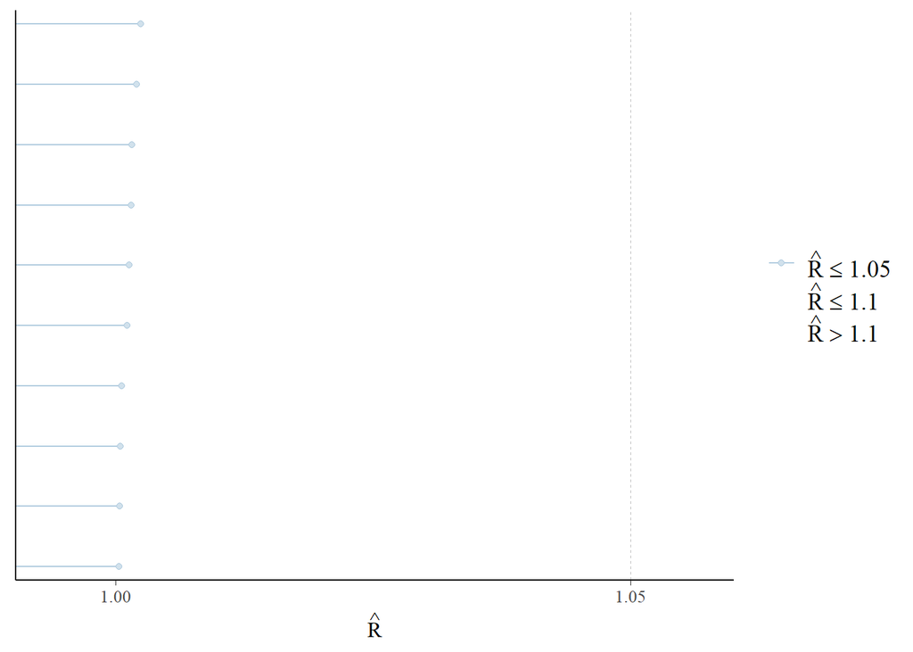

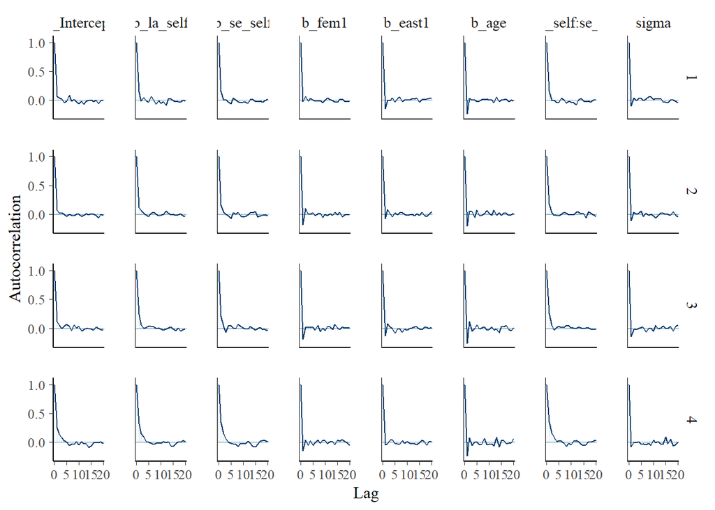

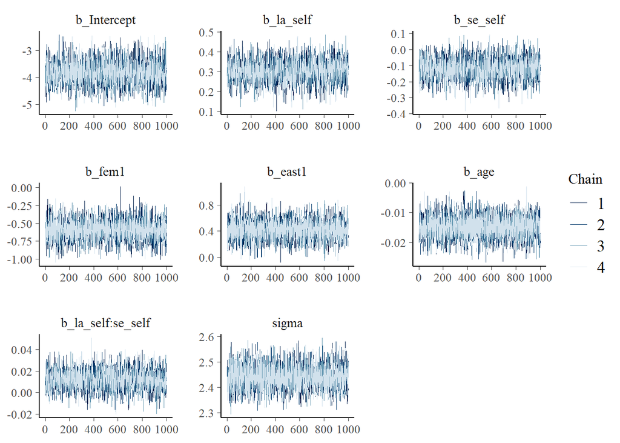

*Quick guides on interpretation:*

- [Potential scale reduction factor (`rhat`)](https://mc-stan.org/bayesplot/articles/visual-mcmc-diagnostics.html#mcmc_rhat-mcmc_rhat_hist)
- [Autocorrelation (`acf`)](https://mc-stan.org/bayesplot/articles/visual-mcmc-diagnostics.html#autocorrelation)
- [Trace plot (`trace`)](https://mc-stan.org/bayesplot/articles/visual-mcmc-diagnostics.html#mcmc_trace)

See `help(mcmc_plot)` for additional types of plots.

### 5.3 Algorithm-specific diagnostics

Note: We rely on the `check_hmc_diagnostics()` function from the `rstan` package. To ensure it works, we must extract the `stanfit` object nested in our `brmsfit` object via `lm_brms$fit`.

```
##
## Divergences:
```

```
## 0 of 4000 iterations ended with a divergence.
```

```
##
## Tree depth:
```

```
## 0 of 4000 iterations saturated the maximum tree depth of 10.
```

```
##
## Energy:
```

```
## E-BFMI indicated no pathological behavior.
```

*Quick guides on interpretation:*

- [Divergent transitions after warmup](https://mc-stan.org/learn-stan/diagnostics-warnings.html#divergent-transitions-after-warmup)
- [Maximum tree depth](https://mc-stan.org/learn-stan/diagnostics-warnings.html#maximum-treedepth)
- [BFMI low](https://mc-stan.org/learn-stan/diagnostics-warnings.html#bfmi-low)

### 5.4 What if I find signs of non-convergence?

The standard answer is: Increase the length of your chains. It may especially help with warnings about Rhat, ESS, and low BFMI.

But this is not always the optimal strategy, and it may not solve your problem.

So, suppose that after running longer chains, one or several of the following still apply:

- Your algorithm-specific diagnostics throw warnings (that won’t go away)
- Your convergence diagnostics indicate signs of non-convergence (and increasing the warm-up period doesn’t help)
- Your algorithm is painfully slow

### 5.5 Dealing with non-covergence and computational problems

Here are some answers, partly based on [Gelman et al. (2020)](https://arxiv.org/abs/2011.01808) and the Stan Development Team’s guide [*Runtime warnings and convergence problems*](https://mc-stan.org/misc/warnings.html):

- Do read [*Runtime warnings and convergence problems*](https://mc-stan.org/misc/warnings.html). It can help you understand a specific problem and potential solutions.
- Do you get algorithm-specific warnings about divergences/max_treedepth? Adjust the HMC/NUTS control arguments `adapt_delta`, `stepsize`, and/or `max_treedepth`.
- Check if your model is well specified (e.g., do you have problems of separation in logistic regression?)
- Adopt an efficient workflow for debugging:
  - Reduce model complexity. [Start with a simpler specification, gradually build up.](https://hyunjimoon.github.io/SBC/articles/small_model_workflow.html) See where things start to go wrong.
  - Use smaller sets of data, few chains, and short runs.
- Optimize priors:
  - If you use custom priors: Do your priors allow for posterior density in regions where you’d expect it?
  - If you use default flat or very vague priors: Use stronger priors (within reason)

## 6 Presentation

### 6.1 Vincent AB’s universe

[Vincent Arel-Bundock](https://arelbundock.com/) has authored and maintains an excellent collection of R packages for the post-estimation presentation of statistical results, including:

- [`modelsummary`](https://modelsummary.com/): Beautiful, customizable, publication-ready data and model summaries in R
- [`marginaleffects`](https://marginaleffects.com/): R package to compute and plot predictions, slopes, marginal means, and comparisons

These packages not only come with incredible flexibility (see the links for details) but also apply to countless classes of statistical models in R (including both frequentist/likelihood-based and Bayesian models).

### 6.2 Tables

```r
modelsummary::modelsummary(
  list("Model 1" = lm_brms),
  statistic = c("SD" = "({std.dev})",
                "95% CI" = "[{conf.low}, {conf.high}]"),
  coef_rename = c(
    "b_Intercept" = "Intercept",
    "b_la_self" = "Anti-immigration",
    "b_se_self" = "Pro-redistribution",
    "se_self" = "Pro-redistribution",
    "sigma" = "σ"
  ),
  coef_omit = c("fem1|east1|age"),
  gof_map = "nobs",
  conf_level = 0.95,
  centrality = "mean",
  output = "flextable",
  align = "lc",
  title = paste(
    "Bayesian linear regression of AfD support on preferences for",
    "immigration restriction and redistribution."
  ),
  notes = paste(
    "Posterior means with posterior standard deviations and",
    "95% credible intervals in parentheses.",
    "Background covariates (omitted from table): age, gender, East/West."
  )
) %>%
  flextable::autofit()
```

Bayesian linear regression of AfD support on preferences for immigration restriction and redistribution.

|  | Model 1 |
| --- | --- |
| Intercept | -3.815 |
|  | (0.428) |
|  | [-4.633, -2.952] |
| Anti-immigration | 0.304 |
|  | (0.054) |
|  | [0.196, 0.410] |
| Pro-redistribution | -0.120 |
|  | (0.065) |
|  | [-0.250, 0.006] |
| Anti-immigration:Pro-redistribution | 0.012 |
|  | (0.009) |
|  | [-0.006, 0.030] |
| σ | 2.442 |
|  | (0.045) |
|  | [2.356, 2.532] |
| Num.Obs. | 1321 |

Posterior means with posterior standard deviations and 95% credible intervals in parentheses. Background covariates (omitted from table): age, gender, East/West.

### 6.3 Quantities of interest (QOIs)

1. **Expected values**: Predicted levels of the outcome variable
   1. For hypothetical observations
   2. Over the values of a focal predictor, holding all else constant
2. **Average first differences:** Effects of categorical predictors
   1. For binary comparisons
   2. For multi-group comparisons** $\rightarrow$ pairwise binary comparisons
3. **Average marginal effects:** Effects of continuous predictors

### 6.4 Application: marginaleffects

The [`marginaleffects`](https://marginaleffects.com/) package (“Predictions, Comparisons, Slopes, Marginal Means, and Hypothesis Tests”), allows users to *“compute and plot predictions, slopes, marginal means, and comparisons (contrasts, risk ratios, odds, etc.) for over 100 classes of statistical and machine learning models in R”*.

A few years ago, compatibility with `brms` models was added.

Below, we apply the package commands to our model, `lm_brms`, which includes a *continuous interaction effect*.

### 6.5 Conditional expected values

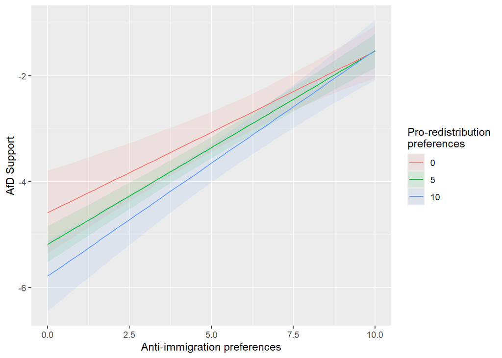

### 6.6 Conditional marginal effects

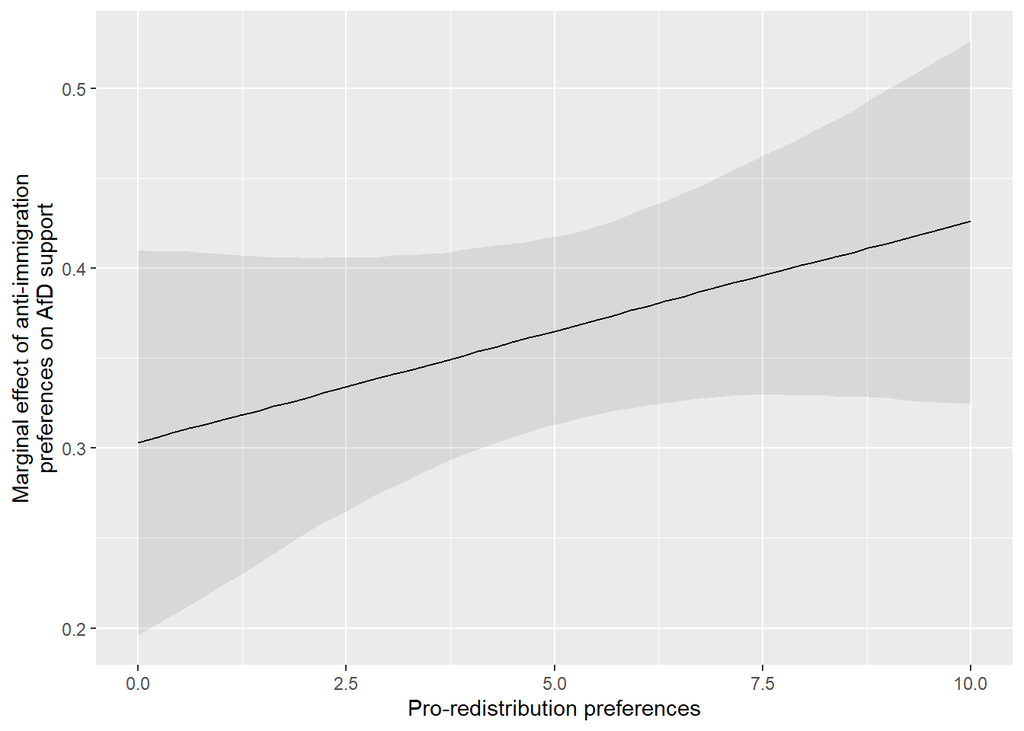

Which substantive conclusions can we draw?

### 6.7 Further reading

See the `marginaleffects` [Case Study 8: Bayes](https://marginaleffects.com/articles/brms.html) for a complete overview of the package’s compatibility with `brms`.

## 7 Posterior predictive checks

Posterior predictive checks involve simulating the data-generating process to obtain replicated data given the estimated model. They can help us determine how well our model fits the data.

This usually involves two questions:

1. Does the *family* yield an adequate generative model?
   - Does a Gaussian (normal) data-generating processes produce realistic replications of the observed values of `sup_afd` (support for the AfD on the -5 to +5 scale)?
   - Does the simulated distribution of the replications match the observed distribution of the outcome in the *sample*?
2. Does the *systematic component* accurately predict outcomes?
   - Do our predictors accurately predict which individuals are more likely to support the AfD?
   - How large is the *observation-level discrepancy* between simulated replications and observed data?

### 7.1 Distributional congruence

To check whether the generative model produces distributions of replicated outcomes that match the distribution of the observed outcome, we can compare the density of the observed outcome with those of, say, `ndraws = 100` simulations. Each simulation is based on one post-warm-up sample from the posterior distribution.

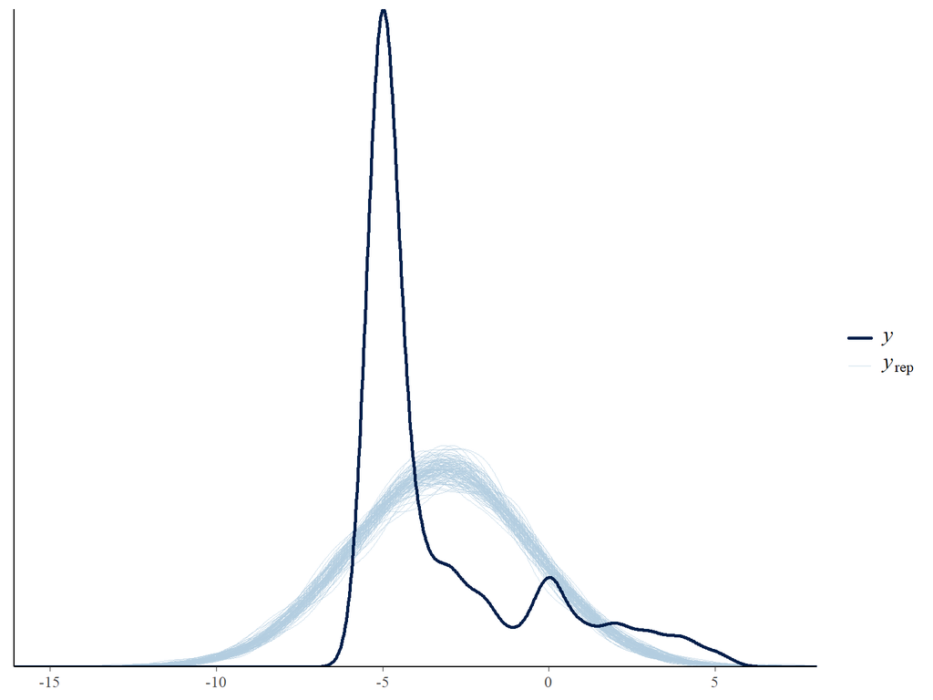

```r
brms::pp_check(lm_brms, ndraws = 100, type = "dens_overlay")
```

So, what do you think?

### 7.2 Observation-level prediction error

To check the predictive accuracy of the model, we can investigate the distribution of observation-level prediction errors. A model with perfect fit would produce an error of $0$ for all $N$ observations.

Below, you see the distribution of errors for our linear model. What do you think?

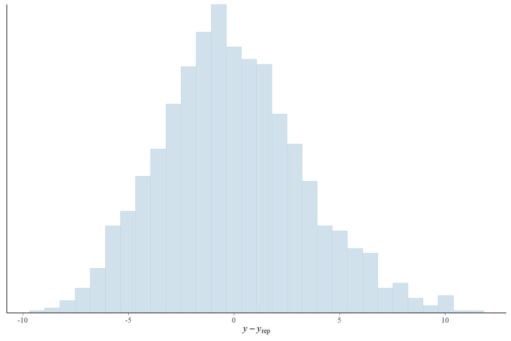

```r
brms::pp_check(lm_brms, ndraws = 1, type = "error_hist")
```

### 7.3 Comparison: the model as a zero-one-inflated beta (ZOIB) regression

Zero-one-inflated beta (ZOIB) regression models bounded continuous outcomes on the unit (i.e., $[0,1]$) interval.

The ZOIB model is a GLM with a multi-family likelihood, meaning that its likelihood is composed of a mixture of several constitutive likelihoods. Specifically, it supplements a beta pdf for values $y \in ]0, 1[$ with additional pmfs for the boundary values $y \in \{0,1\}$.

To model a bounded continuous outcome on the unit interval, we must transform the scale of AfD support to range from 0 to 1 (with midpoint 0.5) instead of -5 to +5 (with midpoint 0), but we will scale it back later on.

We first observe the distributional congruence of the ZOIB-generated outcome simulations.

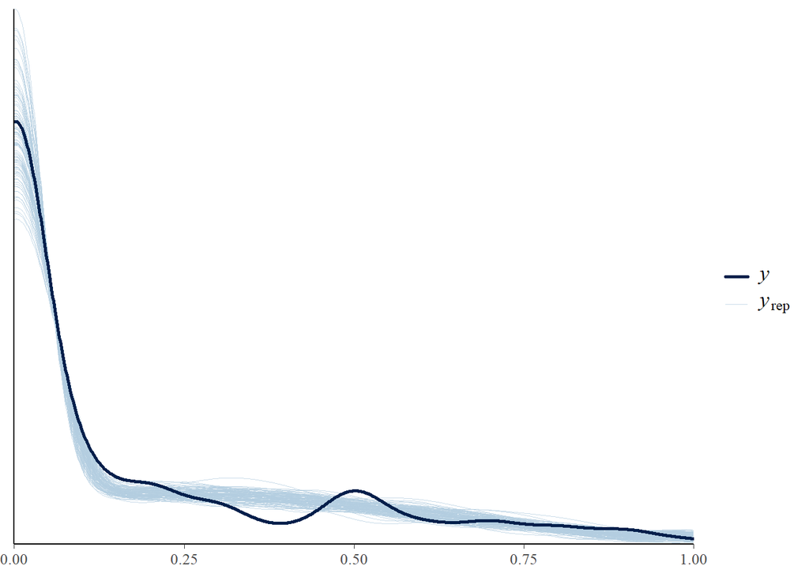

```r
brms::pp_check(zoib_brms, ndraws = 100, type = "dens_overlay")
```

We then turn to checking observation-level prediction errors.

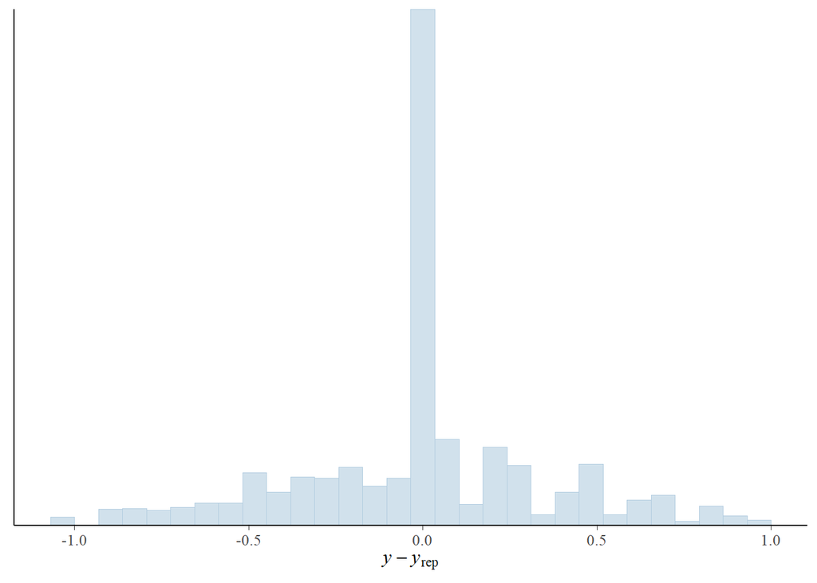

```r
brms::pp_check(zoib_brms, ndraws = 1, type = "error_hist")
```

What do you conclude? Does the ZOIB-family accurately model the observed sample-level distribution of the outcome? Are you happy with the predictive accuracy of our current systematic component?